# Exploring the CitiBike Data in New York

## Exploring the New York City CitiBike data

This project explores the CitiBike program data from New York City.

A few notes:

- The full project (Github repo) can be found [here](https://mrkaye97.github.io/CitiBike/).
- All R code is in `~/CitiBike/R`
- All python code is in `~/CitiBike/python`
- Some data used in certain files can be found in `~/CitiBike/data`, but much is pulled directly from online sources.

## Setup

The project requires no explicit setup. All data is either included in this repo or comes directly from the CitiBike website.

A handful of R and Python packages are needed to run the project. See the bottom of this README for a list.

## Data

The data comes from the [CitiBike program](https://www.citibikenyc.com/system-data) directly, and is publicly available for download.

```r
PROJECT_ROOT <- find_root('CitiBike.Rproj')
```

Below is a glimpse at the structure of the data

```r
fread(paste(PROJECT_ROOT, '/data/citibike_dat_1.csv', sep = ""), verbose = F, showProgress = F) %>%
  mutate(starttime = starttime %>% as_datetime(),
         stoptime = stoptime %>% as_datetime(),
         bikeid = bikeid %>% as.factor()) %>%
  sample_n(size = 100) %>%
  glimpse()
```

```
## Rows: 100
## Columns: 15
## $ tripduration              <int> 607, 689, 553, 1801, 1771, 572, 252, 1201, …
## $ starttime                 <dttm> 2020-03-09 15:31:31, 2020-03-03 17:24:18, …
## $ stoptime                  <dttm> 2020-03-09 15:41:39, 2020-03-03 17:35:47, …
## $ `start station id`        <int> 3132, 3345, 368, 426, 2017, 402, 456, 3256,…
## $ `start station name`      <chr> "E 59 St & Madison Ave", "Madison Ave & E 9…
## $ `start station latitude`  <dbl> 40.76351, 40.78949, 40.73039, 40.71755, 40.…
## $ `start station longitude` <dbl> -73.97109, -73.95243, -74.00215, -74.01322,…
## $ `end station id`          <int> 3372, 3507, 317, 514, 3814, 293, 468, 3166,…
## $ `end station name`        <chr> "E 74 St & 1 Ave", "Park Ave & E 124 St", "…
## $ `end station latitude`    <dbl> 40.76897, 40.80456, 40.72454, 40.76088, 40.…
## $ `end station longitude`   <dbl> -73.95482, -73.93969, -73.98185, -74.00278,…
## $ bikeid                    <fct> 17062, 28356, 18467, 29370, 20164, 34378, 4…
## $ usertype                  <chr> "Customer", "Subscriber", "Subscriber", "Cu…
## $ `birth year`              <int> 1950, 1982, 1989, 1995, 1992, 1970, 1962, 1…
## $ gender                    <int> 0, 2, 1, 2, 2, 1, 1, 1, 1, 1, 2, 1, 0, 1, 1…
```

## Plots

#### Visualizing Commute Patterns – Heatmap of start and end stations by time of day

[figure not shown]

#### Coronavirus Impact on Ridership

[figure not shown]

#### Common Routes

```r
df <- read.csv('https://raw.githubusercontent.com/mrkaye97/CitiBike/master/data/for_common_routes_leaflet.csv')

grouped_coords <- function(coord, group, order) {
  data.frame(coord = coord, group = group) %>%
    group_by(group) %>%
    purrrlyr::by_slice(~c(.$coord, NA), .to = "output") %>%
    left_join(data.frame(group = group, order = order) %>% distinct(), by = 'group') %>%
    arrange(order) %>%
    .$output %>%
    unlist()
}

pal <- colorFactor(
  palette = "magma", domain = NULL)

# Map using Leaflet R
l <- leaflet(df) %>%
  addProviderTiles("CartoDB.Positron") %>%
  addPolylines(
    lng = ~grouped_coords(lon, routeid, rownames(df)),
    lat = ~grouped_coords(lat, routeid, rownames(df)),
    color = ~pal(df$numroute))
```

[interactive chart not shown]

We might also be interested in a long-term forecast of ridership. First, we inspect how ridership trends over time.

```r
rm(list = ls())

library(bsts)

load(url('https://github.com/mrkaye97/CitiBike/blob/master/R/ridership_bsts.Rdata?raw=true'))

df <- df %>%
  mutate(movavg = zoo::rollmean(numrides, 7, fill, align = 'center', fill = NA))
```

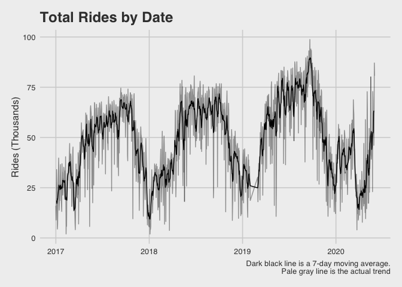

Clearly, this series is highly volatile. We would expect there to be at least two seasonal components at play here: One for the time of the year (better weather in the summer means more bike rides) and one for day of the week (maybe there are more rides on weekdays than weekends because New Yorkers are using the bikes to commute). There is additionally quite likely to be an autoregressive compnent, since the number of rides today likely depends on the number of rides yesterday, and a trend component, since ridership might be increasing over time.

Consider the following plot, which decomposes the time series into its components.

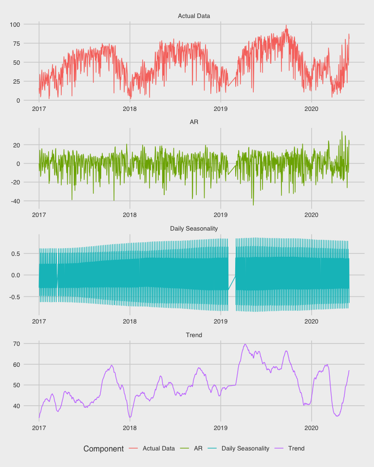